# homework 3

Yichen Lin

2023-04-04

### 1. [Bike Demand]

This problem asks you to visualize a [dataset](https://uwmadison.box.com/shared/static/f16jmkkskylfl1hnd5rpslzduja929g2.csv) of hourly bikeshare demand. Provide your code and make sure it is readable.

```r
bike <- read.csv("https://uwmadison.box.com/shared/static/f16jmkkskylfl1hnd5rpslzduja929g2.csv")
head(bike)
```

```
##       dteday season yr mnth hr holiday weekday temp  hum windspeed count
## 1 2011-01-01      1  0    1  0       0       6 0.24 0.81    0.0000    16
## 2 2011-01-01      1  0    1  1       0       6 0.22 0.80    0.0000    40
## 3 2011-01-01      1  0    1  2       0       6 0.22 0.80    0.0000    32
## 4 2011-01-01      1  0    1  3       0       6 0.24 0.75    0.0000    13
## 5 2011-01-01      1  0    1  4       0       6 0.24 0.75    0.0000     1
## 6 2011-01-01      1  0    1  5       0       6 0.24 0.75    0.0896     1
```

1. Make a line plot of bike demand (`count`) by hour, faceted out across the 7 days of the week (`weekday`).

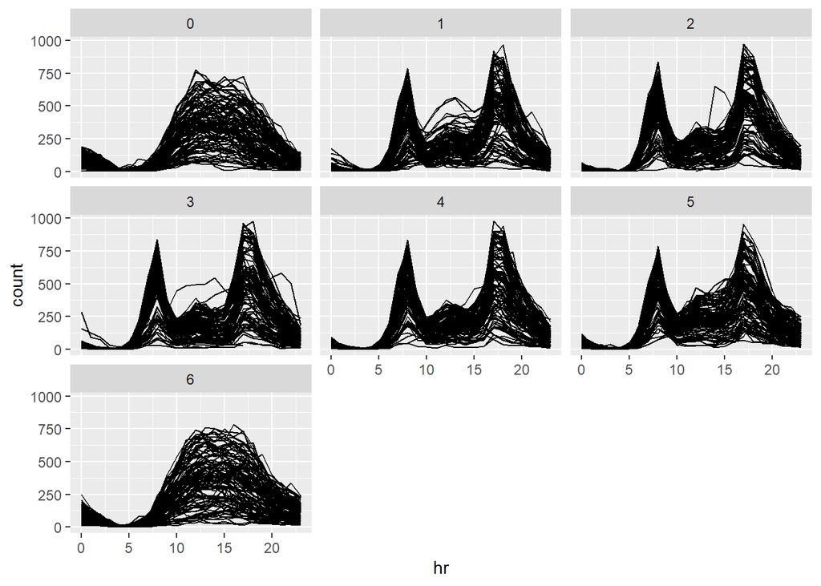

```r
line_plot <-  ggplot(bike) +
  geom_line(aes(x = hr, y = count, group = dteday)) +
  facet_wrap(~ weekday)

line_plot
```

2. Create a new summary data.frame giving the 25 and 75 percent quantiles of demand (`count`) for each hour (`hr`) by day of the week (`weekday`) combination, separately within each year (`yr`) that the data was collected.

```r
new_summary <- bike %>%
  group_by(yr,weekday,hr) %>%
  summarise(q25 = quantile(count,0.25,na.rm = TRUE),
            q75 = quantile(count,0.75,na.rm = TRUE))

new_summary
```

```
## # A tibble: 336 × 5
## # Groups:   yr, weekday [14]
##       yr weekday    hr   q25   q75
##    <int>   <int> <int> <dbl> <dbl>
##  1     0       0     0  39   108.
##  2     0       0     1  33.5  79
##  3     0       0     2  29    65.8
##  4     0       0     3  13.5  35
##  5     0       0     4   3    11
##  6     0       0     5   4     9
##  7     0       0     6   3    16.8
##  8     0       0     7  10    37.2
##  9     0       0     8  33.5  92
## 10     0       0     9  58   172.
## # ℹ 326 more rows
```

3. Using a ribbon plot, overlay the quantities from (b) onto your plot from part (a). Use color to distinguish between the ribbons for the first and second year that the data were collected.

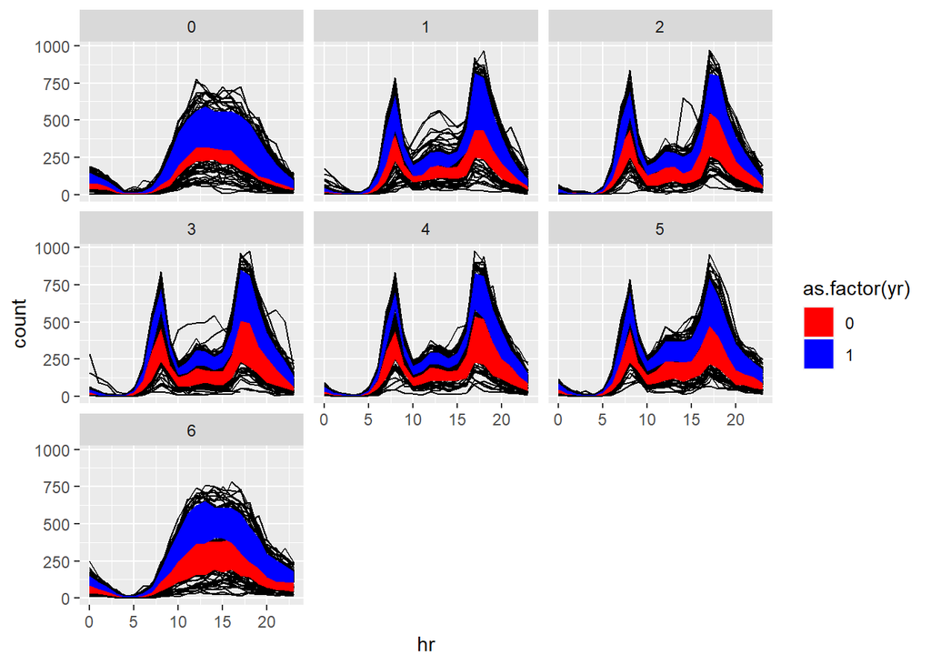

```r
line_plot +
  geom_ribbon(data = new_summary,
              aes(x = hr, ymin = q25, ymax = q75, fill = as.factor(yr))) +
  scale_fill_manual(values = c("red", "blue"))
```

4. Provide a brief description of some takeaways from the final visualization.

For weekdays, there are two strong cyclics at about 7:30 a.m and 17:30 p.m., which corresponds to people’s work hours. During weekend, usage dema nd gradually increases in the morning, reaches its peak at noon, and then gradually decreases.

### 2. [CalFresh Enrollment I]

In this problem, we will investigate spatial and temporal aspects of enrollment in CalFresh, a nutritional assistance program in California.

1. The code below reads in the CalFresh data. We’ve filtered out February 2019, since benefits were distributed differently in this month, leading to outliers for most counties. Extract features of the `calfresh` time series using the `features` function in the feasts library.

```r
library(tsibble)
calfresh <- read.csv("https://uwmadison.box.com/shared/static/rduej9hsc4w3mdethxnx9ccv752f22yr.csv") %>%
  filter(date != "2019 Feb") %>%
  mutate(date = yearmonth(date)) %>%
  as_tsibble(key = county, index = date)

calfresh
```

```
## # A tsibble: 4,872 x 5 [1M]
## # Key:       county [58]
##    county      date medi_cal unemployment calfresh
##    <chr>      <mth> <chr>           <dbl>    <int>
##  1 Alameda 2014 Jan 340 549           6.5    64394
##  2 Alameda 2014 Feb 349 927           6.4    63674
##  3 Alameda 2014 Mar 365 622           6.4    64297
##  4 Alameda 2014 Apr 373 571           5.5    64208
##  5 Alameda 2014 May 378 218           5.6    64582
##  6 Alameda 2014 Jun 381 831           5.9    64635
##  7 Alameda 2014 Jul 385 839           6.3    64020
##  8 Alameda 2014 Aug 389 814           6.1    63835
##  9 Alameda 2014 Sep 393 082           5.5    63346
## 10 Alameda 2014 Oct 396 515           5.4    63146
## # ℹ 4,862 more rows
```

```r
calf <- calfresh %>%
  features(calfresh,feature_set(pkgs ='feasts')) %>%
  left_join(calfresh,by = "county")
calf
```

```
## # A tibble: 4,872 × 39
##    county  trend_strength seasonal_strength_year seasonal_peak_year
##    <chr>            <dbl>                  <dbl>              <dbl>
##  1 Alameda          0.929                  0.321                  5
##  2 Alameda          0.929                  0.321                  5
##  3 Alameda          0.929                  0.321                  5
##  4 Alameda          0.929                  0.321                  5
##  5 Alameda          0.929                  0.321                  5
##  6 Alameda          0.929                  0.321                  5
##  7 Alameda          0.929                  0.321                  5
##  8 Alameda          0.929                  0.321                  5
##  9 Alameda          0.929                  0.321                  5
## 10 Alameda          0.929                  0.321                  5
## # ℹ 4,862 more rows
## # ℹ 35 more variables: seasonal_trough_year <dbl>, spikiness <dbl>,
## #   linearity <dbl>, curvature <dbl>, stl_e_acf1 <dbl>, stl_e_acf10 <dbl>,
## #   acf1 <dbl>, acf10 <dbl>, diff1_acf1 <dbl>, diff1_acf10 <dbl>,
## #   diff2_acf1 <dbl>, diff2_acf10 <dbl>, season_acf1 <dbl>,
## #   lambda_guerrero <dbl>, nsdiffs <int>, bp_stat <dbl>, bp_pvalue <dbl>,
## #   lb_stat <dbl>, lb_pvalue <dbl>, var_tiled_var <dbl>, …
```

2. Visualize CalFresh enrollment over time for the counties with the highest and lowest `seasonal_strength_year`.

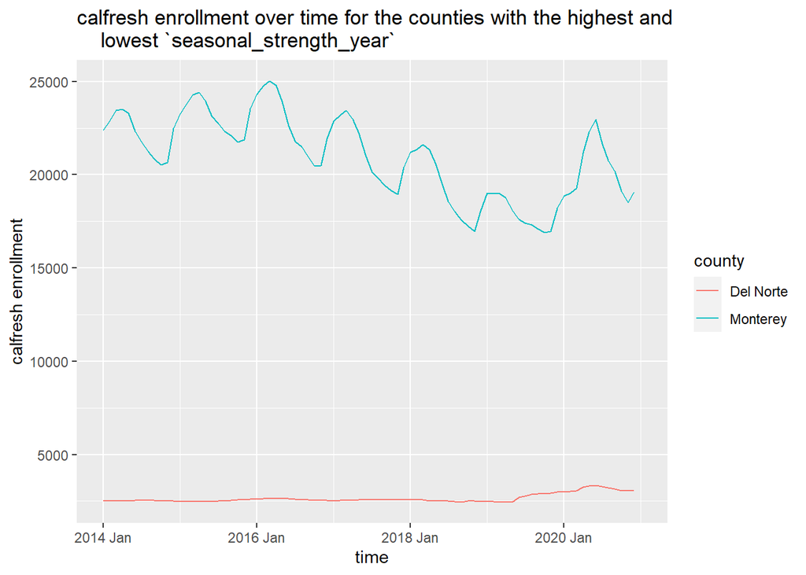

```r
calf %>%
  filter(seasonal_strength_year == max(seasonal_strength_year)) %>%
  pull(county) -> highest_county

calf %>%
  filter(seasonal_strength_year == min(seasonal_strength_year)) %>%
  pull(county) -> lowest_county

Calfresh_enrollment <- calf %>%
  filter(county %in% c(highest_county,lowest_county)) %>%
  ggplot(aes(x = date, y = calfresh, color = county)) +
  geom_line() +
  labs(x = "time", y = "calfresh enrollment",
       title = "calfresh enrollment over time for the counties with the highest and
    lowest `seasonal_strength_year`")

Calfresh_enrollment
```

3. The code below reads in a vector dataset demarcating the county boundaries in California. Join in the features dataset from (a) with this these vector data. Use this to produce a map with each county shaded in by its `seasonal_strength_year`.

```r
library(sf)
counties <- read_sf("https://uwmadison.box.com/shared/static/gropucqxgqm82yhq13do1ws9k16dnxq7.geojson")
joint_calf <- left_join(counties,calf,by = "county")
joint_calf
```

```
## Simple feature collection with 4872 features and 39 fields
## Geometry type: MULTIPOLYGON
## Dimension:     XY
## Bounding box:  xmin: -124.4087 ymin: 32.53429 xmax: -114.1312 ymax: 42.00952
## Geodetic CRS:  WGS 84
## # A tibble: 4,872 × 40
##    county                         geometry trend_strength seasonal_strength_year
##    <chr>                <MULTIPOLYGON [°]>          <dbl>                  <dbl>
##  1 Alameda (((-122.3129 37.89733, -122.28…          0.929                  0.321
##  2 Alameda (((-122.3129 37.89733, -122.28…          0.929                  0.321
##  3 Alameda (((-122.3129 37.89733, -122.28…          0.929                  0.321
##  4 Alameda (((-122.3129 37.89733, -122.28…          0.929                  0.321
##  5 Alameda (((-122.3129 37.89733, -122.28…          0.929                  0.321
##  6 Alameda (((-122.3129 37.89733, -122.28…          0.929                  0.321
##  7 Alameda (((-122.3129 37.89733, -122.28…          0.929                  0.321
##  8 Alameda (((-122.3129 37.89733, -122.28…          0.929                  0.321
##  9 Alameda (((-122.3129 37.89733, -122.28…          0.929                  0.321
## 10 Alameda (((-122.3129 37.89733, -122.28…          0.929                  0.321
## # ℹ 4,862 more rows
## # ℹ 36 more variables: seasonal_peak_year <dbl>, seasonal_trough_year <dbl>,
## #   spikiness <dbl>, linearity <dbl>, curvature <dbl>, stl_e_acf1 <dbl>,
## #   stl_e_acf10 <dbl>, acf1 <dbl>, acf10 <dbl>, diff1_acf1 <dbl>,
## #   diff1_acf10 <dbl>, diff2_acf1 <dbl>, diff2_acf10 <dbl>, season_acf1 <dbl>,
## #   lambda_guerrero <dbl>, nsdiffs <int>, bp_stat <dbl>, bp_pvalue <dbl>,
## #   lb_stat <dbl>, lb_pvalue <dbl>, var_tiled_var <dbl>, …
```

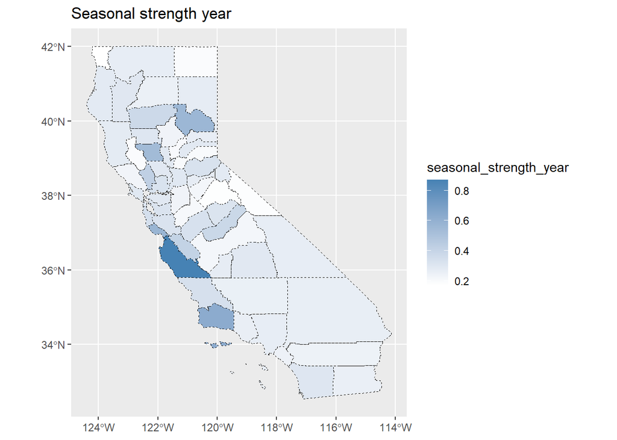

```
d. Propose, but do not implement, a visualization of this dataset that makes use
of dynamic queries. What questions would the visualization answer? What would be
the structure of interaction, and how would the display update when the user
provides a cue?

As a spatial and temporal data set, visualization of it can answer question like
the background of certain county, how the enrollment of this program change over
time in certain county. The users can choose those county that they want to explore
on the map, and a line plot and a table will show information of chosen county.
```

```r
ggplot(joint_calf) +
  geom_sf(aes(fill = seasonal_strength_year,geometry = geometry),
          col = "black", lwd = 0.2, lty = 2) +
  scale_fill_gradient(low = "white",high = "steelblue") +
  labs(title = "Seasonal strength year")
```

### 3. [Political Book Recommendations]

In this problem, we’ll study a network dataset of Amazon bestselling US Politics books. Books are linked by an edge if they appeared together in the recommendations (“customers who bought this book also bought these other books”).

1. The code below reads in the edges and nodes associated with the network. The edges dataset only contains IDs of co-recommended books, while the nodes data includes attributes associated with each book. Build a `tbl_graph` object to store the graph.

```r
edges <- read_csv("https://raw.githubusercontent.com/krisrs1128/stat679_code/main/activities/week10/political-books-edges.csv", col_types = "cci")
nodes <- read_csv("https://raw.githubusercontent.com/krisrs1128/stat679_code/main/activities/week10/political-books-nodes.csv", col_types = "ccc")
```

```r
graph <- tbl_graph(nodes, edges, directed = FALSE)
graph
```

```
## # A tbl_graph: 105 nodes and 441 edges
## #
## # An undirected simple graph with 1 component
## #
## # A tibble: 105 × 3
##   id    label                      political_ideology
##   <chr> <chr>                      <chr>
## 1 0     1000 Years for Revenge     neutral
## 2 1     Bush vs. the Beltway       conservative
## 3 2     Charlie Wilson's War       conservative
## 4 3     Losing Bin Laden           conservative
## 5 4     Sleeping With the Devil    neutral
## 6 5     The Man Who Warned America conservative
## # ℹ 99 more rows
## #
## # A tibble: 441 × 3
##    from    to weight
##   <int> <int>  <int>
## 1     1     2      1
## 2     1     3      1
## 3     1     4      1
## # ℹ 438 more rows
```

2. Use the result from part (a) to visualize the network as a node-link diagram. Include the book’s title in the node label, and shade in the node according to political ideology.

```r
nodes
```

```
## # A tibble: 105 × 3
##    id    label                      political_ideology
##    <chr> <chr>                      <chr>
##  1 0     1000 Years for Revenge     neutral
##  2 1     Bush vs. the Beltway       conservative
##  3 2     Charlie Wilson's War       conservative
##  4 3     Losing Bin Laden           conservative
##  5 4     Sleeping With the Devil    neutral
##  6 5     The Man Who Warned America conservative
##  7 6     Why America Slept          neutral
##  8 7     Ghost Wars                 neutral
##  9 8     A National Party No More   conservative
## 10 9     Bush Country               conservative
## # ℹ 95 more rows
```

```r
# ggraph(graph,layout = "kk") +
#   geom_edge_link() +
#   geom_node_label(aes(label = nodes$label),repel = TRUE) +
#   geom_node_point(aes(color = political_ideology))
```

Due to the limitation of figure size, the screenshot of the figure is as follows:

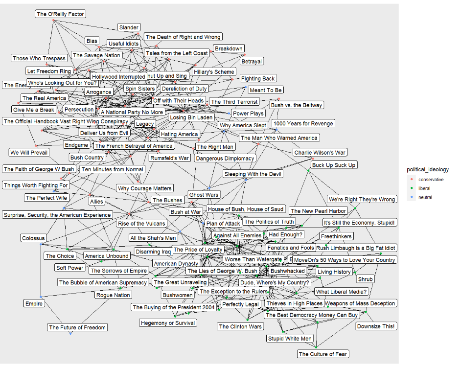

3. Create the analogous adjacency matrix visualization. Provide examples of visual queries that are easy to answer using one encoding but not the other (i.e., what is easy to see in the node-link view vs. what is easy to see in the adjacency matrix).

The visualization is as follows. One example query is that whether it is an inner group or structure within each political ideology. From the output below, there are two or three groups within “conservative” books. And for “liberal” books, there is one big group. Another interesting finding is that from the visualization of the adjacency matrix, books labeled with “neutral” are less likely to connected with each other.

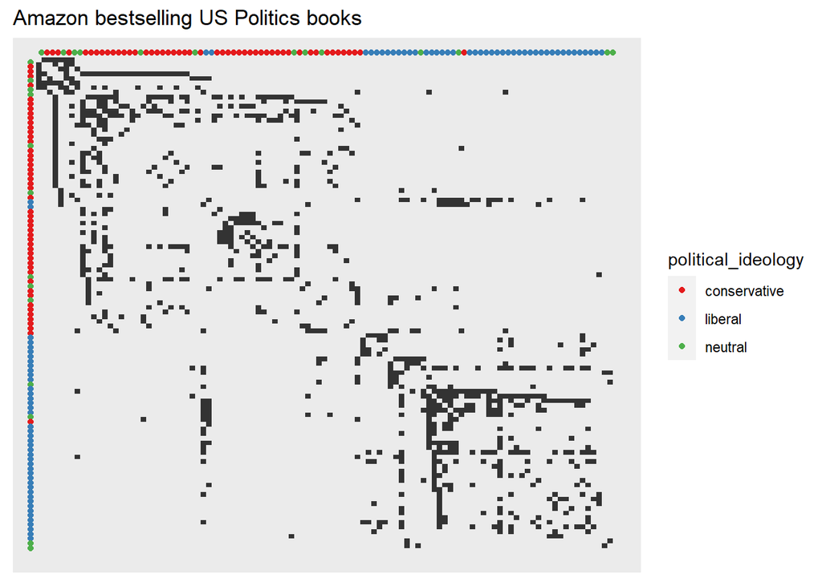

```r
ggraph(graph, "matrix") +
  geom_node_point(aes(col = political_ideology), x = -1) +
  geom_node_point(aes(col = political_ideology), y = 1) +
  geom_edge_tile(mirror = TRUE) +
  scale_y_reverse() +
  scale_color_brewer(palette = "Set1") +
  labs(title = "Amazon bestselling US Politics books")
```

```r
  coord_fixed()
```

[output not shown]

### 4. [NYC Rentals]

In this problem, we’ll create a visualization to dynamically query a [dataset](https://uwmadison.box.com/shared/static/zi72ugnpku714rbqo2og9tv2yib5xped.csv) of Airbnb rentals in Manhattan in 2019. The steps below guide you through the process of building this visualization.

1. Make a scatterplot of locations (Longitude vs. Latitude) for all the rentals, colored in by `room_type`.

```r
NYCrentals <- read.csv("https://uwmadison.box.com/shared/static/zi72ugnpku714rbqo2og9tv2yib5xped.csv")
head(NYCrentals)
```

```
##         id                                               name   host_id
## 1  2619549                Charming, Modern 2BR | Central Park  13347167
## 2 34291583           Sonder | 116 John | Relaxed Studio + Gym 219517861
## 3 16427854       Trendy 1 bedroom apartment in cool LES hood.  83185960
## 4 23901975 BrightClean Studio near Grand Central (MurrayHill)  43275413
## 5 10132356            Giant Loft with a Huge Deck and Kitchen  21247379
## 6  3613839                  Cozy  and sunny room in Manhattan  17450462
##        host_name neighbourhood_group      neighbourhood latitude longitude
## 1 AFI Apartments           Manhattan    Upper East Side 40.77265 -73.95740
## 2   Sonder (NYC)           Manhattan Financial District 40.70838 -74.00694
## 3        Dr. Amy           Manhattan    Lower East Side 40.71510 -73.98661
## 4         Ashumi           Manhattan            Midtown 40.74640 -73.97987
## 5           Paul           Manhattan             Harlem 40.80926 -73.95455
## 6         Esther           Manhattan             Harlem 40.82544 -73.94020
##         room_type price minimum_nights number_of_reviews last_review
## 1 Entire home/apt   140             30                 1  2018-09-30
## 2 Entire home/apt   100             29                 0        <NA>
## 3 Entire home/apt   180              3                49  2019-05-28
## 4 Entire home/apt   180              2                18  2019-06-02
## 5 Entire home/apt   150              3                25  2019-06-14
## 6    Private room    60              7                45  2019-06-09
##   reviews_per_month calculated_host_listings_count availability_365 log_price
## 1              0.11                             29              329  4.941642
## 2                NA                            327              351  4.605170
## 3              1.58                              1                1  5.192957
## 4              1.22                              1                4  5.192957
## 5              1.20                              1               22  5.010635
## 6              0.92                              1              290  4.094345
```

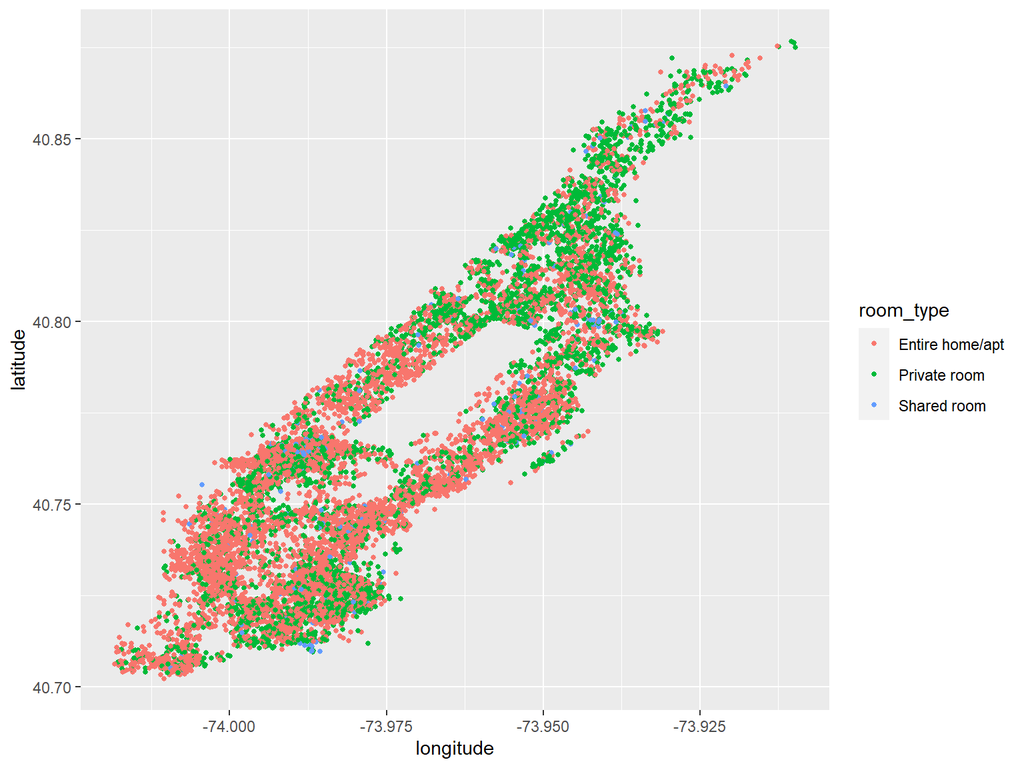

```r
ggplot(NYCrentals) +
  geom_point(aes(x = longitude, y = latitude, col = room_type),size = 1)
```

2. Design a plot and a dynamic query so that clicking or brushing on the plot updates the points that are highlighted in the scatterplot in (a). For example, you may query a histogram of prices to focus on neighborhoods that are more or less affordable.

3. Implement the reverse graphical query. That is, allow the user to update the plot in (b) by brushing over the scatterplot in (a).

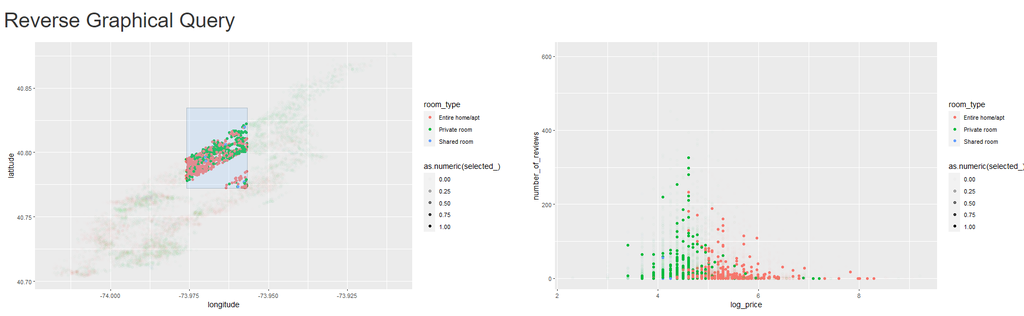

Shiny1

```r
# reset_selected <- function(df, brush) {
#   brushedPoints(df,brush,allRows = TRUE)$selected_
# }
#
# scatter_plot <- function(df,selected, xvar, yvar) {
#   df %>%
#     mutate(selected_ = selected) %>%
#     ggplot(aes_string(x = xvar, y = yvar)) +
#     geom_point(aes(alpha = as.numeric(selected_), col = room_type)) +
#     scale_alpha_continuous(range = c(0.01,1))
# }
#
#
# ui <- fluidPage(
#   titlePanel("Reverse Graphical Query"),
#
#   fluidRow(
#     column(6, plotOutput("scatter1", brush = "plot_brush")),
#     column(6, plotOutput("scatter2", brush = "plot_brush"))
#   )
# )
#
# server <- function(input, output) {
#   selected <- reactiveVal(rep(TRUE,nrow(NYCrentals)))
#
#   observeEvent(
#     input$plot_brush,
#     selected(reset_selected(NYCrentals,input$plot_brush))
#   )
#
#   output$scatter1 <- renderPlot(
#     scatter_plot(NYCrentals,selected(), xvar = "longitude", yvar = "latitude")
#   )
#   output$scatter2 <- renderPlot(
#     scatter_plot(NYCrentals,selected(), xvar = "log_price", yvar = "number_of_reviews")
#   )
# }
#
# shinyApp(ui, server)
```

4. Comment on the resulting visualization(s). If you had a friend who was interested in renting an Airbnb in NYC, what would you tell them?

They can choose rentals within certain range of price and how popular the rantals are, then they can know the location of chosen rooms. To sum up, the shiny app above provide a way that users can choose certain range of price, and visit or rent the most popular rantal.

###5. [Geospatial Datasets] For each of the datasets below, specify whether it is in a vector or raster data format. If it is in a vector data format, explain which types of geometries it contains (e.g., a point or linestring). Explain your reasoning.

1. [NYC Building Footprints](https://uwmadison.box.com/shared/static/qfmrp9srsoq0a7oj0e7xmgu5spojr33e.geojson)

This dataset is a vector dataset which contains polygons information. we can use st_geometry_type function to check which type of geometries this dataset contains. Another reason is that the dataset is stored in .geojson file.

```r
NYC <- read_sf("https://uwmadison.box.com/shared/static/qfmrp9srsoq0a7oj0e7xmgu5spojr33e.geojson")
NYC
```

```
## Simple feature collection with 2726 features and 0 fields
## Geometry type: MULTIPOLYGON
## Dimension:     XY
## Bounding box:  xmin: -74.0048 ymin: 40.7032 xmax: -73.9648 ymax: 40.7432
## Geodetic CRS:  WGS 84
## # A tibble: 2,726 × 1
##                                                                         geometry
##                                                               <MULTIPOLYGON [°]>
##  1 (((-73.99587 40.7432, -73.99348 40.74228, -73.99381 40.74179, -73.99639 40.7…
##  2 (((-74.00315 40.73253, -74.00318 40.73254, -74.00319 40.73255, -74.0031 40.7…
##  3 (((-74.00129 40.72418, -74.00212 40.72305, -74.00277 40.72332, -74.00209 40.…
##  4 (((-73.99679 40.7239, -73.99631 40.7246, -73.99603 40.72449, -73.99652 40.72…
##  5 (((-73.99473 40.72505, -73.99445 40.72575, -73.99433 40.72573, -73.99437 40.…
##  6 (((-73.99951 40.73009, -74.00019 40.72914, -74.00052 40.72927, -74.00047 40.…
##  7 (((-73.992 40.7274, -73.99214 40.72745, -73.99202 40.72761, -73.99192 40.727…
##  8 (((-73.98689 40.714, -73.98707 40.71399, -73.98709 40.71422, -73.98691 40.71…
##  9 (((-73.99174 40.71495, -73.9913 40.71594, -73.99069 40.71578, -73.99113 40.7…
## 10 (((-73.99187 40.71858, -73.99223 40.71778, -73.99293 40.71796, -73.99257 40.…
## # ℹ 2,716 more rows
```

2. [Africa Population 2020](https://github.com/krisrs1128/stat479_s22/blob/main/_slides/week7/exercises/data/afripop2020.tif?raw=true)

It is a raster dataset, which is stored in .tif file. We can also find the data format by the decription below.

```r
Africa <- rast("https://github.com/krisrs1128/stat479_s22/blob/main/_slides/week7/exercises/data/afripop2020.tif?raw=true")
Africa
```

```
## class       : SpatRaster
## dimensions  : 434, 413, 1  (nrow, ncol, nlyr)
## resolution  : 0.1666667, 0.1666667  (x, y)
## extent      : -17.62625, 51.20708, -34.97542, 37.35792  (xmin, xmax, ymin, ymax)
## coord. ref. : lon/lat WGS 84 (EPSG:4326)
## source      : afripop2020.tif?raw=true
## varname     : afripop2020
## name        : afripop2020
## min value   :        0.00
## max value   :    21181.16
```

3. [Himalayan Glacial Lakes](https://github.com/krisrs1128/stat479_s22/tree/main/_slides/week7/exercises/data/glacial_lakes) It is a vector data set in polygon format, because in geometry column it contains “polygon”

```r
Himalayan <- read_sf("C:\\Users\\12927\\Desktop\\visiting\\Courses\\STAT 436\\hw3\\glacial_lakes\\glacial_lakes\\GL_3basins_2015.shp")
Himalayan
```

```
## Simple feature collection with 3624 features and 10 fields
## Geometry type: POLYGON
## Dimension:     XY
## Bounding box:  xmin: 80.07264 ymin: 27.43573 xmax: 88.71977 ymax: 30.62196
## Geodetic CRS:  WGS 84
## # A tibble: 3,624 × 11
##       Id Latitude Longitude GL_ID Basin Sub_Basin   Area Elevation Type  Country
##    <dbl>    <dbl>     <dbl> <chr> <chr> <chr>      <dbl>     <dbl> <chr> <chr>
##  1     1     28.9      86.5 GL08… Koshi Arun      0.917       5098 E(o)  China
##  2     2     28.9      86.5 GL08… Koshi Arun      0.866       5254 E(o)  China
##  3     3     28.8      87.5 GL08… Koshi Arun      0.0427      5402 E(o)  China
##  4     4     28.8      86.5 GL08… Koshi Arun      2.82        5319 E(o)  China
##  5     5     28.8      87.5 GL08… Koshi Arun      0.0789      5453 E(o)  China
##  6     6     28.8      87.5 GL08… Koshi Arun      0.0426      5495 E(o)  China
##  7     7     28.8      87.6 GL08… Koshi Arun      0.0593      5642 E(o)  China
##  8     8     28.8      87.4 GL08… Koshi Arun      0.211       5551 E(o)  China
##  9     9     28.8      87.6 GL08… Koshi Arun      0.273       5316 E(o)  China
## 10    10     28.8      87.6 GL08… Koshi Arun      0.0557      5760 E(o)  China
## # ℹ 3,614 more rows
## # ℹ 1 more variable: geometry <POLYGON [°]>
```

4. [US EV Charging](https://raw.githubusercontent.com/krisrs1128/stat479_s22/main/_slides/week7/exercises/data/ev.geojson)

This is a dataset in point format according to the decription below. Also, another reason is that the dataset is stored in .geojson file.

```r
US <- read_sf("https://raw.githubusercontent.com/krisrs1128/stat479_s22/main/_slides/week7/exercises/data/ev.geojson")
US
```

```
## Simple feature collection with 846 features and 68 fields
## Geometry type: POINT
## Dimension:     XY
## Bounding box:  xmin: -92.75408 ymin: 42.51329 xmax: -87.02122 ymax: 46.94643
## Geodetic CRS:  WGS 84
## # A tibble: 846 × 69
##    OBJECTID FUEL_TYPE_ STATION_NA  STREET_ADD INTERSECTI CITY  STATE ZIP   PLUS4
##       <int> <chr>      <chr>       <chr>      <chr>      <chr> <chr> <chr> <chr>
##  1      235 LPG        AmeriGas    700 Count… Route 12 … Elkh… WI    53121 <NA>
##  2      287 LPG        AmeriGas    4117 Term… Near High… McFa… WI    53558 <NA>
##  3      288 LPG        Ferrellgas  1301 S St… <NA>       Madi… WI    53716 <NA>
##  4      289 LPG        Roche-A-Cr… 503 S Mai… Highway 1… Adams WI    53910 <NA>
##  5      290 LPG        United Co-… 7160 N Ra… 0.5 mile … Beav… WI    53916 <NA>
##  6      291 LPG        Lakes Gas … 50 Packer… Off Highw… Robe… WI    54023 <NA>
##  7      292 LPG        Ferrellgas  801 Prosp… East on C… Osce… WI    54020 <NA>
##  8      293 LPG        Superior G… 212 W 14t… 1.5 block… Mars… WI    54449 <NA>
##  9      294 LPG        AmeriGas    112 S Par… Near High… Rhin… WI    54501 <NA>
## 10      295 LPG        Midland Se… 411 Sanbo… From the … Ashl… WI    54806 <NA>
## # ℹ 836 more rows
## # ℹ 60 more variables: STATION_PH <chr>, STATUS_COD <chr>, EXPECTED_D <date>,
## #   GROUPS_WIT <chr>, ACCESS_DAY <chr>, CARDS_ACCE <chr>, BD_BLENDS <chr>,
## #   NG_FILL_TY <chr>, NG_PSI <chr>, EV_LEVEL1_ <chr>, EV_LEVEL2_ <chr>,
## #   EV_DC_FAST <chr>, EV_OTHER_I <chr>, EV_NETWORK <chr>, EV_NETWO_1 <chr>,
## #   GEOCODE_ST <chr>, LATITUDE <dbl>, LONGITUDE <dbl>, DATE_LAST_ <date>,
## #   ID <int>, UPDATED_AT <date>, OWNER_TYPE <chr>, FEDERAL_AG <chr>, …
```

5. [Zion Elevation](https://github.com/krisrs1128/stat479_s22/blob/main/_slides/week7/exercises/data/landsat.tif?raw=true) This is a raster dataset which is stored in .tif file. Another reason is as following code.

```r
Zion <- rast("https://github.com/krisrs1128/stat479_s22/blob/main/_slides/week7/exercises/data/landsat.tif?raw=true")
Zion
```

```
## class       : SpatRaster
## dimensions  : 1428, 1128, 4  (nrow, ncol, nlyr)
## resolution  : 30, 30  (x, y)
## extent      : 301905, 335745, 4111245, 4154085  (xmin, xmax, ymin, ymax)
## coord. ref. : WGS 84 / UTM zone 12N (EPSG:32612)
## source      : landsat.tif?raw=true
## varname     : landsat
## names       : landsat_1, landsat_2, landsat_3, landsat_4
## min values  :      7550,      6404,      5678,      5252
## max values  :     19071,     22051,     25780,     31961
```

###6. [Olympics Interactive App] The code below sets up a Shiny app for interactively visualizing athlete weight and heights in the 2012 London Olympics. We would like to have an interactive scatterplot of `Weight` vs. `Height, cm` that updates which points (athletes) are highlighted depending on which sports have been selected by a dropdown menu. Code for generating the scatterplot is provided in the function `scatterplot`.

```r
# library(shiny)
# library(tidyverse)
# olympics <- read.csv("https://uwmadison.box.com/shared/static/rzw8h2x6dp5693gdbpgxaf2koqijo12l.csv")
#
# #' Scatterplot with highlighted points
# #'
# #' Assumes a column in df called "selected" saying whether points should be
# #' larger / darker
# scatterplot <- function(df) {
#   ggplot(df) +
#     geom_point(aes(
#       Weight,
#       Height..cm,
#       alpha = as.numeric(selected),
#       size = as.numeric(selected)
#     )) +
#     scale_alpha(range = c(0.05, .8)) +
#     scale_size(range = c(0.1, 1))
# }
#
# ui <- fluidPage(
#   selectInput(
#     "dropdown",
#     "Select a Sport",
#     choices = unique(olympics$Sport),
#     multiple = TRUE
#   ),
#   plotOutput("scatterplot")
# )
#
# server <- function(input, output) {
#   # fill this in...
#
#   output$scatterplot <- renderPlot({olympics %>%
#                                      mutate(selected = Sport %in% input$dropdown) %>%
#                                      scatterplot()})
# }
```

1. Provide server code which would allow the scatterplot to update the highlighted athletes depending on the currently selected sports.

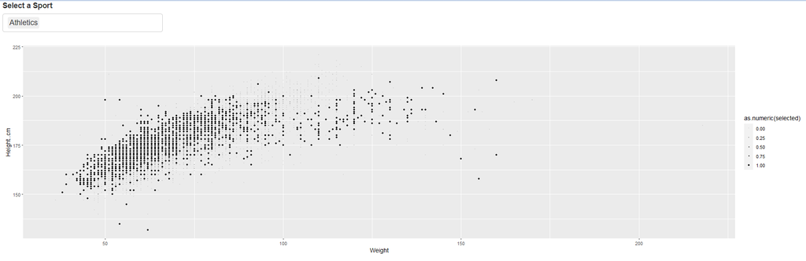

Shiny2

```r
# shinyApp(ui,server)
```

2. We have been asked to also print a table of the selected athletes. Assume the UI has the form,

   ```r
   # ui <- fluidPage(
   #   selectInput("dropdown", "Select a Sport", choices = unique(olympics$Sport), multiple = TRUE),
   #   plotOutput("scatterplot"),
   #   dataTableOutput("table")
   # )
   ```

Describe changes to your solution to (a) to meet the new requirements. How would you minimize code duplication? Be as specific as possible.

1. Add an reactive expression to dynamically select the required athletes.
2. use “renderTable” function to ouput the result of the table. Brief Code:

```r
# server <- function(input, output) {
#   ### other code ###
#   selected_athlete <- reactive ({
#     olympics %>%
#       mutate(selected = Sport %in% input$dropdown)
#   })
#   ### other code ###
#
#   output$table <- renderTable(selected_athlete)
#   ### other code ###
# }
```